# Data Visualization Part 2: Student Project

## Matriculation Number : 22203735

### 1: Visualization Exercises

##### Three alternative visualizations of the same artificial data shall be re-created. All three visualizations show the same fictitious genomic annotations together with fictitious RNA binding protein data. The visualizations are an example for RNA binding protein signals as well as the genomic annotations. Recreate each of the shown figures. Two different datasets are provided for this task:

##### - 10_project_data_annotations.csv

##### - 10_project_data_signals.csv

##### The 10_project_data_annotations.csv file contains fictitious genomic information as visualized in all bottom panels of the example plots. Each horizontal line represents a transcript. A transcript can contain multiple exons (grey rectangles). Transcripts can be located on the '+' or on the '-' strand of the DNA.

##### - 10_project_data_signals.csv contains fictitious signals of four RNA binding proteins (P1, P2, P3, P4).

```python
#Importing all the required libraries for the assignment!

import pandas as pd
import matplotlib.pyplot as plt
import numpy as np
from matplotlib.collections import PatchCollection
```

##### 1.1: Version 1

```python
# Loading the datasets
dfann = pd.read_csv('E:/LIFE SCIENCE INFORMATICS [DIT]/SEMESTER - 02 [SUMMER SEMESTER]/DATA VISUALIZATION/PROJECT PART 2/datavis_final_project_23/10_project_data_annotation.csv')
dfsig = pd.read_csv('E:/LIFE SCIENCE INFORMATICS [DIT]/SEMESTER - 02 [SUMMER SEMESTER]/DATA VISUALIZATION/PROJECT PART 2/datavis_final_project_23/10_project_data_signals.csv')

# Inspect the datasets
print(dfann.head())
print(dfsig.head())
```

```
    name        type  start   stop strand
0  geneA  transcript   2000   7764      +
1  geneA        exon   2700   5100      +
2  geneA        exon   6000   6800      +
3  geneB  transcript   9000  12720      -
4  geneB        exon   9900  10100      -
     P1    P2    P3    P4
0  0.28  0.14  0.19  0.19
1  0.30  0.16  0.17  0.20
2  0.26  0.13  0.20  0.12
3  0.21  0.13  0.25  0.15
4  0.31  0.03  0.24  0.20
```

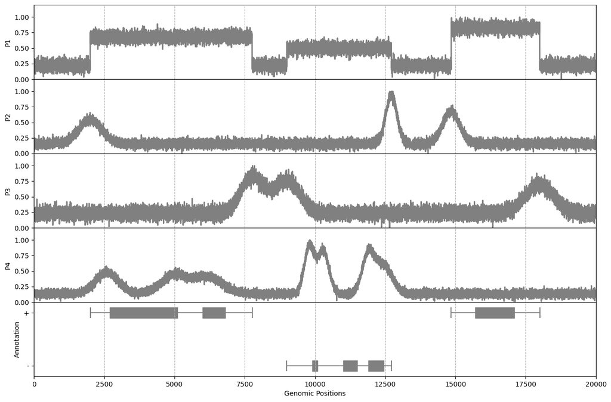

```python
patches=[]
#selecting the rows with the exon type and creating the width column and filling it with the difference of each start and stop positions .
#I have created another column 'y' where i transformed the strand values by 0 and 1.

dfexon = dfann.loc[dfann['type'] == 'exon']
dfexon['width'] = dfexon['stop']-dfexon['start']
dfexon["y"] = np.where(dfexon['strand']=='+',1,0)

#selecting the rows with the transcript type.I created another column 'y' where i transformed the strand value by 0 and 1.
dftrans = dfann.loc[dfann['type'] == 'transcript']
dftrans["y"] = np.where(dftrans['strand']=='+',1,0)

#create the rectangles and save them in patches list
for i in range(len(dfexon)):
    rectangle=plt.Rectangle((dfexon["start"].iloc[i],dfexon['y'].iloc[i]-0.2/2),width=dfexon["width"].iloc[i],height=0.2, facecolor="gray", edgecolor="gray")
    patches.append(rectangle)

#The function to draw different plots
def plot_signals(mat):
        #creating the first plot and initialising other 5 plots
        fig,ax=plt.subplots(5)
        x= np.arange(20000)

        #set the size of the first plot
        fig.set_size_inches(15,10)

        #remove the space between plots
        fig.subplots_adjust(hspace=0)

        #set x and y limits
        ax[0].set_xlim([0,20000])
        ax[0].set_ylim([0,1.2])

        #hide x labels and label the firt draw then plot it
        ax[0].set_xticklabels([])
        ax[0].set_ylabel('P1')
        ax[0].plot(x,mat[:,0],linewidth=2,zorder=2,color='gray')

        #True to make the grid lines visible, axis x means vertical lines
        ax[0].grid(True,which='major', axis='x', linestyle='--')


        #set the size of the second plot
        fig.set_size_inches(15,10)

        #remove the space between plots
        fig.subplots_adjust(hspace=0)

        #set x and y limits
        ax[1].set_xlim([0,20000])
        ax[1].set_ylim([0,1.2])

        #hide x labels and label the draw then plot it
        ax[1].set_xticklabels([])
        ax[1].set_ylabel('P2')
        ax[1].plot(x,mat[:,1],linewidth=2,zorder=2,color='gray')

        #True to make the grid lines visible, axis x means vertical lines
        ax[1].grid(True,which='major', axis='x', linestyle='--')

        #set the size of the third plot
        fig.set_size_inches(15,10)

        #remove the space between plots
        fig.subplots_adjust(hspace=0)

        #set x and y limits
        ax[2].set_xlim([0,20000])
        ax[2].set_ylim([0,1.2])

        #hide x labels and label the draw then plot it
        ax[2].set_xticklabels([])
        ax[2].plot(x,mat[:,2],linewidth=2,zorder=2,color='gray')
        ax[2].set_ylabel('P3')

        #True to make the grid lines visible, axis x means vertical lines
        ax[2].grid(True,which='major', axis='x', linestyle='--')


        #set the size of the fourth plot
        fig.set_size_inches(15,10)

        #remove the space between plots
        fig.subplots_adjust(hspace=0)

        #set x and y limits
        ax[3].set_xlim([0,20000])
        ax[3].set_ylim([0,1.2])

        #hide x labels and label the draw then plot it
        ax[3].set_xticklabels([])
        ax[3].plot(x,mat[:,3],linewidth=2,zorder=2,color='gray')
        ax[3].set_ylabel('P4')

        #True to make the grid lines visible, axis x means vertical lines
        ax[3].grid(True,which='major', axis='x', linestyle='--')

        #set the size of the fifth plot
        fig.set_size_inches(15,10)
        ax[4]=plt.gca()

        #remove the space between plots
        fig.subplots_adjust(hspace=0)

        #set x and y limits
        ax[4].set_xlim([0,20000])
        ax[4].set_ylim([-0.2,1.2])

        #set x and y labels
        ax[4].set_xlabel('Genomic Positions')
        ax[4].set_ylabel('Annotation')

        #set y valuess labels to 0 and 1 then name them to '-' and '+'
        ax[4].set_yticks([0, 1])
        ax[4].set_yticklabels(["-", "+"])

        #plotting the rectangles already saved in patches list, preserving the gray color previously assigned to each of them.
        ax[4].add_collection(PatchCollection(patches,match_original=True))

        #plotting the horizontal lines representing transcripts
        ax[4].hlines(dftrans["y"].iloc[0],dftrans["start"].iloc[0],dftrans["stop"].iloc[0],color='gray')
        ax[4].hlines(dftrans["y"].iloc[1],dftrans["start"].iloc[1],dftrans["stop"].iloc[1],color='gray')
        ax[4].hlines(dftrans["y"].iloc[2],dftrans["start"].iloc[2],dftrans["stop"].iloc[2],color='gray')

        #plotting vertical lines to illustrate both ends of each transcript
        ax[4].vlines(dftrans["start"].iloc[0],dftrans["y"].iloc[0]-0.1,dftrans["y"].iloc[0]+0.1,color='gray')
        ax[4].vlines(dftrans["stop"].iloc[0],dftrans["y"].iloc[0]-0.1,dftrans["y"].iloc[0]+0.1,color='gray')
        ax[4].vlines(dftrans["start"].iloc[1],dftrans["y"].iloc[1]-0.1,dftrans["y"].iloc[1]+0.1,color='gray')
        ax[4].vlines(dftrans["stop"].iloc[1],dftrans["y"].iloc[1]-0.1,dftrans["y"].iloc[1]+0.1,color='gray')
        ax[4].vlines(dftrans["start"].iloc[2],dftrans["y"].iloc[2]-0.1,dftrans["y"].iloc[2]+0.1,color='gray')
        ax[4].vlines(dftrans["stop"].iloc[2],dftrans["y"].iloc[2]-0.1,dftrans["y"].iloc[2]+0.1,color='gray')

        #True to make the grid lines visible,axis x means vertical lines
        ax[4].grid(True,which='major', axis='x', linestyle='--')


#Calling the plotting function
plot_signals(dfsig.to_numpy())
```

##### 1.2: Version 2

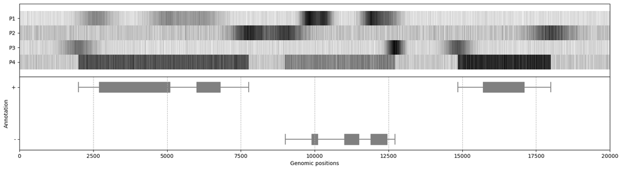

```python
#creating the first plot and initialising 2 plots
fig,ax=plt.subplots(2,1,sharex=True)

#set the size of the first plot
fig.set_size_inches(20,5)

#set x and y limits
ax[0].set_xlim([0,20000])
ax[0].set_ylim([-1,4])

#set y valuess labels to 0, 1, 2 and 3 then name them respectively to'P4', 'P3', 'P2', 'P1'
ax[0].set_yticks([0,1,2,3])
ax[0].set_yticklabels(['P4', 'P3', 'P2', 'P1'])

#creating the x and filling it with ordered position values
x = np.arange(0, len(dfsig["P1"]))

#creating the y and filling it with signal columns numbers
y = np.arange(0, len(dfsig.columns))

#creating list and filling it with our signal dataframe columns
z = [dfsig.P1, dfsig.P2, dfsig.P3, dfsig.P4]

#plotting the colormesh graph with color map gray
ax[0].pcolormesh(x, y, z, shading ='nearest', cmap ='gray_r', vmin=0, vmax=np.max(z))

#setting the size of the 'second' plot
fig.set_size_inches(20,5)
ax[1]=plt.gca()

#removing the space between the two plots
fig.subplots_adjust(hspace=0)

#set x and y limits
ax[1].set_xlim([0,20000])
ax[1].set_ylim([-0.2,1.2])

#set y valuess labels to 0 and 1 then name them to '-' and '+'
ax[1].set_yticks([0, 1])
ax[1].set_yticklabels(["-", "+"])

#set x and y labels
ax[1].set_xlabel('Genomic positions')
ax[1].set_ylabel('Annotation')

#plotting the rectangles already saved in patches list, preserving the gray color previously assigned to each of them.
ax[1].add_collection(PatchCollection(patches,match_original=True))

#plotting the horizontal lines representing transcripts
ax[1].hlines(dftrans["y"].iloc[0],dftrans["start"].iloc[0],dftrans["stop"].iloc[0],color='gray')
ax[1].hlines(dftrans["y"].iloc[1],dftrans["start"].iloc[1],dftrans["stop"].iloc[1],color='gray')
ax[1].hlines(dftrans["y"].iloc[2],dftrans["start"].iloc[2],dftrans["stop"].iloc[2],color='gray')

#plotting vertical lines to illustrate both ends of each transcript
ax[1].vlines(dftrans["start"].iloc[0],dftrans["y"].iloc[0]-0.1,dftrans["y"].iloc[0]+0.1,color='gray')
ax[1].vlines(dftrans["stop"].iloc[0],dftrans["y"].iloc[0]-0.1,dftrans["y"].iloc[0]+0.1,color='gray')
ax[1].vlines(dftrans["start"].iloc[1],dftrans["y"].iloc[1]-0.1,dftrans["y"].iloc[1]+0.1,color='gray')
ax[1].vlines(dftrans["stop"].iloc[1],dftrans["y"].iloc[1]-0.1,dftrans["y"].iloc[1]+0.1,color='gray')
ax[1].vlines(dftrans["start"].iloc[2],dftrans["y"].iloc[2]-0.1,dftrans["y"].iloc[2]+0.1,color='gray')
ax[1].vlines(dftrans["stop"].iloc[2],dftrans["y"].iloc[2]-0.1,dftrans["y"].iloc[2]+0.1,color='gray')
ax[1].grid(True,which='major', axis='x', linestyle='--')
```

##### 1.3: Version 3

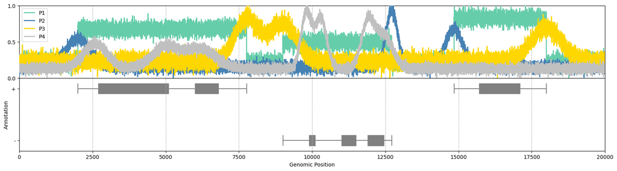

```python
#creating the first plot and initialisingthe other 2 plots
fig,ax=plt.subplots(2,sharex=True)

#creating a labels list of different line plot
l=['P1','P2','P3','P4']

#creating the x array
x= np.arange(20000)

#set the size of the first plot
fig.set_size_inches(20,5)

#remove the space between plots
fig.subplots_adjust(hspace=0)

#set x and y limits
ax[0].set_xlim([0,20000])
ax[0].set_ylim(0,1)

#set y valuess labels to 0, 0.5 and 1
ax[0].set_yticks([0,0.5, 1])

#True to make the grid lines visible,axis x means vertical lines
ax[0].grid(True,which='major', axis='x', linestyle='--')

#set x labels
ax[0].set_xlabel('Genomic positions')

#creating a list of colors for each line plot
color=['#66CDAA','#4682B4','#FFD700','#C0C0C0']
j=0

#Drawing the 4 plots with each color from the list
for i in range(4):
        ax[0].plot(x,dfsig.to_numpy()[:,i],label=l[i],linewidth=2,zorder=5,color=color[j])
        j=j+1

#show the legends on the upper left
ax[0].legend(loc='upper left')

#set the size of the second plot
fig.set_size_inches(20,5)
ax[1]=plt.gca()

#remove the space between plots
fig.subplots_adjust(hspace=0)

#set x and y limits
ax[1].set_xlim([0,20000])
ax[1].set_ylim([-0.2,1.2])

#set y valuess labels to 0 and 1 then name them to '-' and '+'
ax[1].set_yticks([0, 1])
ax[1].set_yticklabels(["-", "+"])

#set x and y labels
ax[1].set_xlabel('Genomic Position')
ax[1].set_ylabel('Annotation')

#plotting the rectangles already saved in patches list, preserving the gray color previously assigned to each of them.
ax[1].add_collection(PatchCollection(patches,match_original=True))

#plotting the horizontal lines representing transcripts
ax[1].hlines(dftrans["y"].iloc[0],dftrans["start"].iloc[0],dftrans["stop"].iloc[0],color='gray')
ax[1].hlines(dftrans["y"].iloc[1],dftrans["start"].iloc[1],dftrans["stop"].iloc[1],color='gray')
ax[1].hlines(dftrans["y"].iloc[2],dftrans["start"].iloc[2],dftrans["stop"].iloc[2],color='gray')

#plotting vertical lines to illustrate both ends of each transcript
ax[1].vlines(dftrans["start"].iloc[0],dftrans["y"].iloc[0]-0.1,dftrans["y"].iloc[0]+0.1,color='gray')
ax[1].vlines(dftrans["stop"].iloc[0],dftrans["y"].iloc[0]-0.1,dftrans["y"].iloc[0]+0.1,color='gray')
ax[1].vlines(dftrans["start"].iloc[1],dftrans["y"].iloc[1]-0.1,dftrans["y"].iloc[1]+0.1,color='gray')
ax[1].vlines(dftrans["stop"].iloc[1],dftrans["y"].iloc[1]-0.1,dftrans["y"].iloc[1]+0.1,color='gray')
ax[1].vlines(dftrans["start"].iloc[2],dftrans["y"].iloc[2]-0.1,dftrans["y"].iloc[2]+0.1,color='gray')
ax[1].vlines(dftrans["stop"].iloc[2],dftrans["y"].iloc[2]-0.1,dftrans["y"].iloc[2]+0.1,color='gray')

#True to make the grid lines visible,axis x means vertical lines
ax[1].grid(True,which='major', axis='x', linestyle='--')
```

### 2: Visualization Exercises

##### In this task, two additional plots shall be added create a figure with multiple panels. Recreate the shown figure. Note, that the bottom part of the figure is one of your solutions from the first exercise. Two additional datasets are provided:

##### - 10_project_data_scatter.csv contains the data needed to create the shown scatter plot

##### - 10_project_data_barplot.csv contains the data needed to create the shown bar plot.

```python
# Loading the datasets
dfscat = pd.read_csv('E:/LIFE SCIENCE INFORMATICS [DIT]/SEMESTER - 02 [SUMMER SEMESTER]/DATA VISUALIZATION/PROJECT PART 2/datavis_final_project_23/10_project_data_scatter.csv')
dfbar = pd.read_csv('E:/LIFE SCIENCE INFORMATICS [DIT]/SEMESTER - 02 [SUMMER SEMESTER]/DATA VISUALIZATION/PROJECT PART 2/datavis_final_project_23/10_project_data_barplot.csv')

# Inspect the datasets
print(dfscat.head())
print(dfbar)
```

```
      x1    x2
0   8.41  5.43
1   9.56  3.92
2  10.83  1.80
3  11.14  2.32
4  11.41  1.41
  Unnamed: 0  condition_a_sample_1  condition_a_sample_2  control
0         XY                   756                   619      689
1         XZ                  2411                  2189      782
2         YX                   577                   821      689
3         YZ                   743                   781      719
```

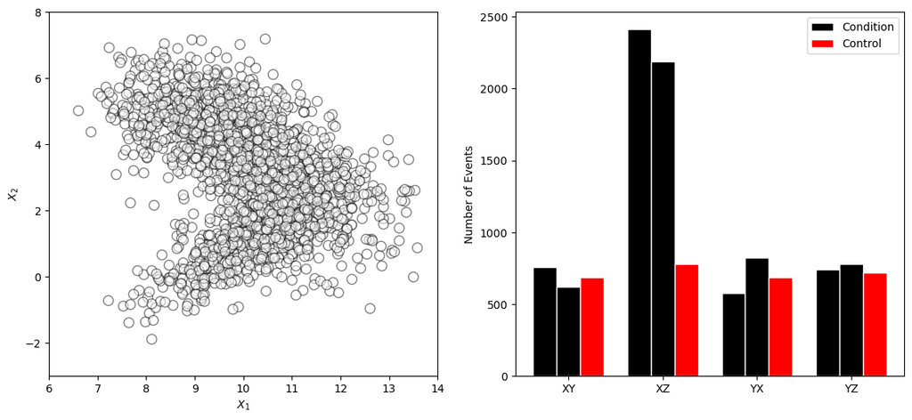

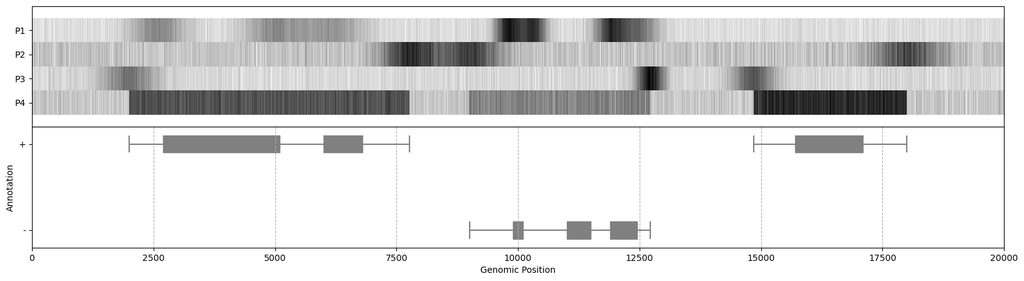

```python
fig, ax = plt.subplots(1,2)
fig.set_size_inches(14,6)

x_1 = dfscat['x1']
x_2 = dfscat['x2']

ax[0].scatter(dfscat['x1'], dfscat['x2'], s=80, alpha=0.5, edgecolors='#000000', color='white')

ax[0].set_xlabel('$X_1$')
ax[0].set_ylabel('$X_2$')

ax[0].set_xlim([6,14])
ax[0].set_ylim([-3,8])

# set width of bars
barWidth = 0.25

# set heights of bars
bars1 = [756,2411,577,743]
bars2 = [619,2189,821,781]
bars3 = [689,782,689,719]

# Set position of bar on X axis
r1 = np.arange(len(bars1))
r2 = [x + barWidth for x in r1]
r3 = [x + barWidth for x in r2]

# Make the plot
ax[1].bar(r1, bars1, color='black', width=barWidth, edgecolor='white', label='Condition')
ax[1].bar(r2, bars2, color='black', width=barWidth, edgecolor='white')
ax[1].bar(r3, bars3, color='red', width=barWidth, edgecolor='white', label='Control')

# Add xticks on the middle of the group bars
ax[1].set_ylabel('Number of Events', fontweight=20)
ax[1].set_xticks([r + barWidth for r in range(len(bars1))], ["XY", "XZ", "YX", "YZ"])

# Create legend
ax[1].legend()


#drawing the first plot and initialising 2 plots
fig,ax=plt.subplots(2,1,sharex=True)

#set the size of the first plot
fig.set_size_inches(20,5)

#set x and y limits
ax[0].set_xlim([0,20000])
ax[0].set_ylim([-1,4])

#set y valuess labels to 0.5, 1.5, 2.5 and 3.5 then name them respectively to'P4', 'P3', 'P2', 'P1'
ax[0].set_yticks([0,1,2,3])
ax[0].set_yticklabels(['P4', 'P3', 'P2', 'P1'])

#creating the x and filling it with ordered position values
x = np.arange(0, len(dfsig["P1"]))

#creating the y and filling it with signal columns numbers
y = np.arange(0, len(dfsig.columns))

#creating list and filling it with our signal dataframe columns
z = [dfsig.P1, dfsig.P2, dfsig.P3, dfsig.P4]

#plotting the colormesh graph with color map gray
ax[0].pcolormesh(x, y, z, shading ='nearest', cmap ='gray_r', vmin=0, vmax=np.max(z))

#setting the size of the 'second' plot
fig.set_size_inches(20,5)
ax[1]=plt.gca()

#removing the space between the two plots
fig.subplots_adjust(hspace=0)

#set x and y limits
ax[1].set_xlim([0,20000])
ax[1].set_ylim([-0.2,1.2])

#set y valuess labels to 0 and 1 then name them to '-' and '+'
ax[1].set_yticks([0, 1])
ax[1].set_yticklabels(["-", "+"])

#set x and y labels
ax[1].set_xlabel('Genomic Position')
ax[1].set_ylabel('Annotation')

#plotting the rectangles already saved in patches list, preserving the gray color previously assigned to each of them.
ax[1].add_collection(PatchCollection(patches,match_original=True))

#plotting the horizontal lines representing transcripts
ax[1].hlines(dftrans["y"].iloc[0],dftrans["start"].iloc[0],dftrans["stop"].iloc[0],color='gray')
ax[1].hlines(dftrans["y"].iloc[1],dftrans["start"].iloc[1],dftrans["stop"].iloc[1],color='gray')
ax[1].hlines(dftrans["y"].iloc[2],dftrans["start"].iloc[2],dftrans["stop"].iloc[2],color='gray')

#plotting vertical lines to illustrate both ends of each transcript
ax[1].vlines(dftrans["start"].iloc[0],dftrans["y"].iloc[0]-0.1,dftrans["y"].iloc[0]+0.1,color='gray')
ax[1].vlines(dftrans["stop"].iloc[0],dftrans["y"].iloc[0]-0.1,dftrans["y"].iloc[0]+0.1,color='gray')
ax[1].vlines(dftrans["start"].iloc[1],dftrans["y"].iloc[1]-0.1,dftrans["y"].iloc[1]+0.1,color='gray')
ax[1].vlines(dftrans["stop"].iloc[1],dftrans["y"].iloc[1]-0.1,dftrans["y"].iloc[1]+0.1,color='gray')
ax[1].vlines(dftrans["start"].iloc[2],dftrans["y"].iloc[2]-0.1,dftrans["y"].iloc[2]+0.1,color='gray')
ax[1].vlines(dftrans["stop"].iloc[2],dftrans["y"].iloc[2]-0.1,dftrans["y"].iloc[2]+0.1,color='gray')
ax[1].grid(True,which='major', axis='x', linestyle='--')
```

### 3: 2-mer Counts In Sequence Data

##### The file 10_project_data_dna_sequences.txt consists of DNA sequences. Each line is a single DNA sequence. The figure shows that some k-mers are concentrated (occur more often) in some regions of the sequences. To recreate the figure you need to count the occurrences of a kmer at each position for all sequences.

##### Example: imagine to search for "xx" and "yy" in following sequences.

##### TCTAAGGxxyyG

##### xxCGTGGyyCGT

##### TTTxxACCGyyG

##### AGCxxACAACyy

##### TAxxCAAyyAGT

##### The counts for "xx" and "yy" would be the following:

[1 0 1 2 0 0 0 1 0 0 0 0]

[0 0 0 0 0 0 0 2 0 2 1 0]

##### Recreate the shown figure be providing code to find the 2-mers in the given dataset as well as the code to display the 2-mer occurences per position.

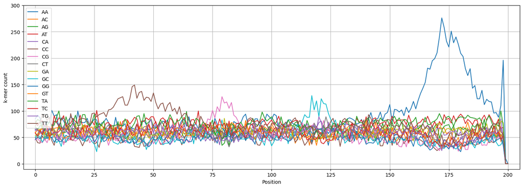

```python
#Loading the dataset
with open ('10_project_data_dna_sequences.txt', 'r') as file:
    sequences = file.readlines()

#creating dictionary for the k-mers
kmer_dict = dict()
kmers = ['AA', 'AC', 'AG', 'AT', 'CA', 'CC', 'CG', 'CT', 'GA', 'GC', 'GG', 'GT', 'TA', 'TC', 'TG', 'TT']
for k_mer in kmers:
     kmer_dict[k_mer] = np.zeros(len(sequences[0]))

#sorting the k-mers in the sequence data
for i in range(len(sequences)):
    sequence = sequences[i]
    for j in range(len(sequence)):
        kmer = sequence[j: j + 2]
        if kmer in kmers:
             kmer_dict[kmer][j]+=1

#creating plot and setting the size
fig, ax = plt.subplots()
fig.set_size_inches(18, 6)

#setting the limits for the axes(x,y)
ax.set_xlim(-5, 205)
ax.set_ylim(-10,300)

#ploting the lines
for kmer in kmers:
    ax.plot(kmer_dict[kmer], label=kmer)

#labelling the plot
ax.set_xlabel('Position')
ax.set_ylabel('k-mer count')
ax.legend(loc="upper left")
ax.grid()
```